# 数学建模

### 模型知识点

### 预测模型-数据拟合

**Wang Haihua**

🚅 🚋😜 🚑 🚔

拟合是用一个连续函数（曲线）靠近给定的离散数据，使其与给定的数据相吻合。 数据拟合的算法相对比较简单，但调用不同工具和方法时的函数定义和参数设置有所差异。 本文基于 Scipy 工具包，对单变量、多变量线性最小二乘拟合，指数函数、多项式函数、样条函数的非线性拟合，单变量、多变量的自定义函数拟合问题进行分析、给出完整例程和结果，数据拟合从此无忧。

## 1. 数据拟合

在科学研究和工程应用中经常通过测量、采样、实验等方法获得各种数据。对一组已知数据点集，通过调整拟合函数（曲线）的参数，使该函数与已知数据点集相吻合，这个过程称为数据拟合，又称曲线拟合。

插值和拟合都是根据一组已知数据点，求变化规律和特征相似的近似曲线的过程。但是插值要求近似曲线完全经过所有的给定数据点，而拟合只要求近似曲线在整体上尽可能接近数据点，并反映数据的变化规律和发展趋势。因此插值可以看作是一种特殊的拟合，是要求误差函数为 0 的拟合。

### 1.1 数据拟合问题的分类

数据拟合问题，可以从不同角度进行分类：

按照拟合函数分类，分为线性函数和非线性函数。非线性函数用于数据拟合，常用的有多项式函数、样条函数、指数函数和幂函数，针对具体问题还有自定义的特殊函数显示。 按照变量个数分类，分为单变量函数和多变量函数。 按照拟合模型分类，分为基于模型的数据拟合和无模型的函数拟合。基于模型的数据拟合，是通过建立数学模型描述输入输出变量之间的关系，拟合曲线不仅能拟合观测数据，拟合模型的参数通常具有明确的物理意义。而无模型的函数拟合，是指难以建立描述变量关系的数学模型，只能采用通用的函数和曲线拟合观测数据，例如多项式函数拟合、样条函数拟合，也包括机器学习和神经网络模型，这种模型的参数通常没有明确的意义。

### 1.2 数据拟合的原理和方法

数据拟合通过调整拟合函数中的待定参数，从整体上接近已知的数据点集。

这是一个优化问题，决策变量是拟合函数的待定参数，优化目标是观测数据与拟合函数的函数值之间的某种误差指标。典型的优化目标是拟合函数值与观测值的误差平方和；当观测数据的重要性不同或分布不均匀时，也可以使用加权误差平方和作为优化目标。

[figure not shown]

[figure not shown]

对于非线性函数的拟合问题，通常也是按照最小二乘法的思路，求解上述误差平方和最小化这个非线性优化问题，常用的具体算法有搜索算法和迭代算法两类。

### 1.3 Python 数据拟合方法

数据拟合是常用算法，Python 语言的很多工具包都提供了数据拟合方法，常用的如 Scipy、Numpy、Statsmodel、Scikit-learn 工具包都带有数据拟合的函数与应用。

Scipy 是最常用的 Python 工具包，本系列中非线性规划、插值方法也都是使用 Scipy 工具包实现，因此仍以 Scipy 工具包讲解数据拟合问题。

Scipy 工具包对于不同类型的数据拟合问题，提供了不同的函数或类。由于 Scipy 工具包是多个团队合作完成，而且经过了不断更新，因此调用不同函数和方法时的函数定义和参数设置有所差异，往往使小白感到困惑。

本文对单变量、多变量线性最小二乘拟合，指数函数、多项式函数、样条函数的非线性拟合，单变量、多变量的自定义函数拟合问题进行分析、给出完整例程和结果，数据拟合从此无忧。

## 2. 线性最小二乘拟合

### 2.1 线性最小二乘拟合函数说明

线性最小二乘拟合是最简单和最常用的拟合方法。scipy.optimize 工具箱中的 leastsq()、lsq_linear()，scipy.stats 工具箱中的 linregress()，都可以实现线性最小二乘拟合。

#### 2.1.1 scipy.optimize.leastsq 函数说明

`scipy.optimize.leastsq(func, x0, args=(), Dfun=None, full_output=0, col_deriv=0, ftol=1.49012e-08, xtol=1.49012e-08, gtol=0.0, maxfev=0, epsfcn=None, factor=100, diag=None)`

主要参数：

#### 2.1.2 scipy.stats.linregress 函数说明

`scipy.stats.linregress(x, y=None, alternative='two-sided')`

主要参数：

x, y：x, y 是长度相同的一维数组。或者 x 是二维数组，且 y=none，则二维数组 x 相当于 长度相同的一维数组 x, y。 返回值：

### 2.2 Python 例程：单变量线性拟合

程序说明：

scipy.optimize.leastsq() 与 scipy.stats.linregress() 都可以进行单变量线性拟合。leastsq() 既可以用于单变量也可以用于多变量问题；linregress() 只能用于单变量问题，但可以给出很多参数估计的统计结果。 leastsq() 要以子函数来定义观测值与拟合函数值的误差函数，例程中分别定义了拟合函数 fitfunc1(p, x) 与误差函数error1(p, x, y) ，是为了方便调用拟合函数计算拟合曲线在数据点的函数值。注意 p 为数组 。 leastsq() 中误差函数的函数名可以任意定义，但误差函数的参数必须按照 (p,x,y) 的顺序排列，不能改变次序。 leastsq() 中观测数据 (x, yObs) 是以动态参数 args 的方式进行传递的。这种处理方式非常独特，没有为什么， leastsq() 就是这样定义的。 linregress() 只要将观测数据 (x,yObs) 作为参数，默认单变量线性拟合，不需要定义子函数。 leastsq() 与 linregress() 进行线性拟合，得到的参数估计结果是相同的。 Python 例程：

```python
# 1. 单变量线性拟合：最小二乘法 scipy.optimize.leastsq
import numpy as np
import matplotlib.pyplot as plt  # 导入 Matplotlib 工具包
from scipy.optimize import leastsq  # 导入 scipy 中的最小二乘法拟合工具
from scipy.stats import linregress  # 导入 scipy 中的线性回归工具

def fitfunc1(p, x):  # 定义拟合函数为直线
    p0, p1 = p  # 拟合函数的参数
    y = p0 + p1*x  # 拟合函数的表达式
    return y

def error1(p, x, y):  # 定义观测值与拟合函数值的误差函数
    err = fitfunc1(p,x) - y  # 误差
    return err
```

```python
# 创建给定数据点集 (x,yObs)
p = [2.5, 1.5]  # y = p[0] + p[1] * x
x = np.array([0., 0.5, 1.5, 2.5, 4.5, 5.5, 7.5, 8.0, 8.5, 9.0, 10.0])
y = p[0] + p[1] * x  # 理论值 y
np.random.seed(1)
yObs = y + np.random.randn(x.shape[-1])  # 生成带有噪声的观测数据
# print(x.shape, y.shape, yObs.shape)
```

```python
# 由给定数据点集 (x,y) 求拟合函数的参数 pFit
p0 = [1, 1]  # 设置拟合函数的参数初值
pFit, info = leastsq(error1, p0, args=(x,yObs))  # 最小二乘法求拟合参数
print("Data fitting with Scipy.optimize.leastsq")
print("y = p[0] + p[1] * x")
print("p[0] = {:.4f}\np[1] = {:.4f}".format(pFit[0], pFit[1]))

# 由拟合函数 fitfunc 计算拟合曲线在数据点的函数值
yFit = fitfunc1(pFit,x)
```

```python
# 比较：线性回归，可以返回斜率，截距，r 值，p 值，标准误差
slope, intercept, r_value, p_value, std = linregress(x, yObs)
print("\nLinear regress with Scipy.stats.linregress")
print("y = p[0] + p[1] * x")
print("p[0] = {:.4f}".format(intercept))  # 输出截距 intercept
print("p[1] = {:.4f}".format(slope))  # 输出斜率 slope
print("r^2_value: {:.4f}".format(r_value**2))  # 输出 r^2 值
print("p_value: {:.4f}".format(p_value))  # 输出 p 值
print("std: {:.4f}".format(std))  # 输出标准差 std
```

```
Data fitting with Scipy.optimize.leastsq
y = p[0] + p[1] * x
p[0] = 2.2688
p[1] = 1.5528

Linear regress with Scipy.stats.linregress
y = p[0] + p[1] * x
p[0] = 2.2688
p[1] = 1.5528
r^2_value: 0.9521
p_value: 0.0000
std: 0.1161
```

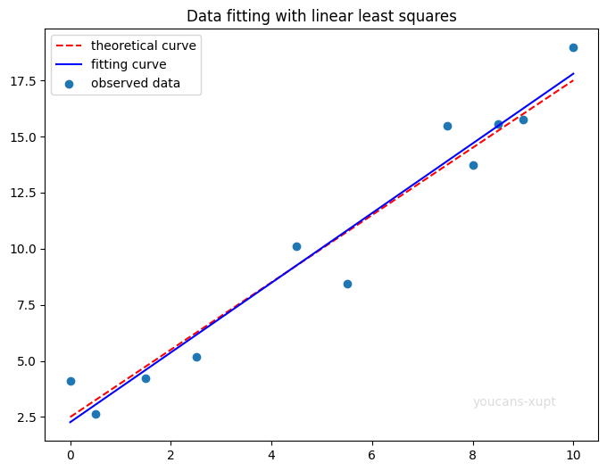

```python
# 绘图
fig, ax = plt.subplots(figsize=(8,6))
ax.text(8,3,"youcans-xupt",color='gainsboro')
ax.set_title("Data fitting with linear least squares")
plt.scatter(x, yObs, label="observed data")
plt.plot(x, y, 'r--', label="theoretical curve")
plt.plot(x, yFit, 'b-', label="fitting curve")
plt.legend(loc="best")
plt.show()
```

### 2.3 Python 例程：多变量线性拟合

程序说明：

scipy.optimize.leastsq() 既可以用于单变量也可以用于多变量问题，本例程求解一个二元线性拟合问题：y = p[0] + p[1] *x1 + p[2]* x2。 leastsq() 求解多变量问题的方法与单变量问题类似，以子函数 error2(p, x1, x2, y) 来定义观测值与拟合函数值的误差函数，以动态参数 args 的方式传递观测数据 (x, yObs) 。 leastsq() 中误差函数的函数名可以任意定义，但误差函数的参数必须按照 (p,x1,x2,y) 的顺序排列，不能改变次序。 scipy 只能做一元线性回归，例程中通过调用 statsmodels.api 进行多元线性回归，可以得到各种统计参数，供读者参考。 Python 例程：

```python
# 2. 多变量线性拟合：最小二乘法 scipy.optimize.leastsq
import numpy as np
import matplotlib.pyplot as plt  # 导入 Matplotlib 工具包
from scipy.optimize import leastsq  # 导入 scipy 中的最小二乘法工具

def fitfunc2(p, x1, x2):  # 定义拟合函数为直线
    p0, p1, p2 = p  # 拟合函数的参数
    y = p0 + p1*x1 + p2*x2  # 拟合函数的表达式
    return y

def error2(p, x1, x2, y):  # 定义观测值与拟合函数值的误差函数
    err = fitfunc2(p, x1, x2) - y  # 计算残差
    return err

# 创建给定数据点集 (x,yObs)
np.random.seed(1)
p = [2.5, 1.5, -0.5]  # y = p[0] + p[1] * x1 + p[2] * x2
x1 = np.array([0., 0.5, 1.5, 2.5, 4.5, 5.5, 7.5, 8.0, 8.5, 9.0, 10.0])
x2 = np.array([0., 1.0, 1.5, 2.2, 4.8, 5.0, 6.3, 6.8, 7.1, 7.5, 8.0])
z = p[0] + p[1]*x1 + p[2]*x2  # 理论值 z
zObs = z + np.random.randn(x1.shape[-1])  # 生成带有噪声的观测数据
print(x1.shape, z.shape, zObs.shape)
```

```python
# 由给定数据点集 (x,z) 求拟合函数的参数 pFit
p0 = [1, 1, 1]  # 设置拟合函数的参数初值
pFit, info = leastsq(error2, p0, args=(x1,x2,zObs))  # 最小二乘法求拟合参数
print("Data fitting with Scipy.optimize.leastsq:")
print("z = p[0] + p[1]*x1 + p[1]*x2")
print("p[0]={:.4f}\np[1]={:.4f}\np[2]={:.4f}".format(pFit[0], pFit[1], pFit[2]))

# 由拟合函数 fitfunc 计算拟合曲线在数据点的函数值
zFit = fitfunc2(pFit, x1, x2)
```

```python
# 多元线性回归：最小二乘法(OLS)
import statsmodels.api as sm
x0 = np.ones(x1.shape[-1])  # 截距列 x0=[1,...1]
X = np.column_stack((x0, x1, x2))  # (nSample,3): [x0, x1, x2]
model = sm.OLS(zObs, X)  # 建立 OLS 模型: y = b0*x0 + b1*x1 + b2*x2 + e
results = model.fit()  # 返回模型拟合结果
zFit = results.fittedvalues  # 模型拟合的 y值
print(results.summary())  # 输出回归分析的摘要
print("\nOLS model: y = b0*x0 + b1*x1 + b2*x2")
print('Parameters: ', results.params)  # 输出：拟合模型的系数
```

```
(11,) (11,) (11,)
Data fitting with Scipy.optimize.leastsq:
z = p[0] + p[1]*x1 + p[1]*x2
p[0]=2.6463
p[1]=2.2410
p[2]=-1.3710
                            OLS Regression Results
==============================================================================
Dep. Variable:                      y   R-squared:                       0.922
Model:                            OLS   Adj. R-squared:                  0.902
Method:                 Least Squares   F-statistic:                     47.21
Date:                Sat, 23 Oct 2021   Prob (F-statistic):           3.72e-05
Time:                        15:02:23   Log-Likelihood:                -17.382
No. Observations:                  11   AIC:                             40.76
Df Residuals:                       8   BIC:                             41.96
Df Model:                           2
Covariance Type:            nonrobust
==============================================================================
                 coef    std err          t      P>|t|      [0.025      0.975]
------------------------------------------------------------------------------
const          2.6463      0.942      2.808      0.023       0.473       4.820
x1             2.2410      1.043      2.148      0.064      -0.165       4.647
x2            -1.3710      1.312     -1.045      0.326      -4.396       1.654
==============================================================================
Omnibus:                        0.439   Durbin-Watson:                   3.144
Prob(Omnibus):                  0.803   Jarque-Bera (JB):                0.488
Skew:                          -0.082   Prob(JB):                        0.783
Kurtosis:                       1.981   Cond. No.                         35.4
==============================================================================

Notes:
[1] Standard Errors assume that the covariance matrix of the errors is correctly specified.

OLS model: y = b0*x0 + b1*x1 + b2*x2
Parameters:  [ 2.64628055  2.24100973 -1.37104475]
```

## 3. 非线性函数数据拟合

### 3.1 非线性拟合函数说明

非线性函数是非常广泛的概念。本节讨论指数函数、多项式函数和样条函数三种常用的通用形式的非线性函数拟合问题，分别使用了 Scipy 工具包中的 `scipy.optimize.leastsq()`、`scipy.linalg.lstsq()` 和 `scipy.interpolate.UnivariateSpline()` 函数。

scipy.optimize.leastsq() 的使用方法已在本文 2.1 中进行了介绍，scipy.interpolate.UnivariateSpline() 的使用方法在《22. 插值方法》文中进行了介绍，以下介绍 `scipy.linalg.lstsq()` 函数。

lstsq() 函数只要传入观测数据 (x,yObs)，并将 x 按多项式阶数转换为 X，即可求出多项式函数的系数，不需要定义拟合函数或误差函数，非常适合比较不同阶数的多项式函数拟合的效果。

`scipy.linalg.lstsq(a, b, cond=None, overwrite_a=False, overwrite_b=False, check_finite=True, lapack_driver=None)`

主要参数：

a：(m,n) 数组，表示方程 Ax=b 的左侧。 b：(m,) 数组，表示方程 Ax=b 的右侧。 返回值：

### 3.2 Python 例程：指数函数拟合

程序说明：

```python
# 3. 非线性函数拟合：指数函数拟合(exponential function)
import numpy as np
import matplotlib.pyplot as plt  # 导入 Matplotlib 工具包
from scipy.optimize import leastsq  # 导入 scipy 中的最小二乘法工具

def fitfunc3(p, x):  # 定义拟合函数
    p0, p1, p2 = p  # 拟合函数的参数
    y = p0 + p1 * np.exp(-p2*x)  # 拟合函数的表达式
    return y

def error3(p, x, y):  # 定义残差函数
    err = fitfunc3(p,x) - y  # 残差
    return err

# 创建给定数据点集 (x,yObs)
p = [0.5, 2.5, 1.5]  # y = p0 + p1 * np.exp(-p2*x)
x = np.linspace(0, 5, 50)
y = fitfunc3(p, x)
np.random.seed(1)
yObs = y + 0.2*np.random.randn(x.shape[-1])  # 生成带有噪声的观测数据
# print(x.shape, y.shape, yObs.shape)
```

```python
# 由给定数据点集 (x,y) 求拟合函数的参数 pFit
p0 = [1, 1, 1]  # 设置拟合函数的参数初值
pFit, info = leastsq(error3, p0, args=(x,yObs))  # 最小二乘法求拟合参数
print("Data fitting of exponential function")
print("y = p0 + p1 * np.exp(-p2*x)")
print("p[0] = {:.4f}\np[1] = {:.4f}\np[2] = {:.4f}".format(pFit[0], pFit[1], pFit[2]))

# 由拟合函数 fitfunc 计算拟合曲线在数据点的函数值
yFit = fitfunc3(pFit, x)
```

```
Data fitting of exponential function
y = p0 + p1 * np.exp(-p2*x)
p[0] = 0.5216
p[1] = 2.5742
p[2] = 1.6875
```

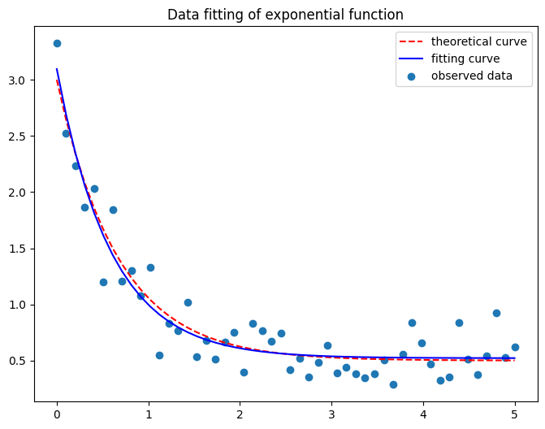

```python
# 绘图
fig, ax = plt.subplots(figsize=(8,6))
ax.set_title("Data fitting of exponential function")
plt.scatter(x, yObs, label="observed data")
plt.plot(x, y, 'r--', label="theoretical curve")
plt.plot(x, yFit, 'b-', label="fitting curve")
plt.legend(loc="best")
plt.show()
```